# Milestone Report - Exploratory Analysis

Taiguara Melo Tupinambas

17 de setembro de 2018

```r
knitr::opts_chunk$set(echo = TRUE)
library('tm')
library('wordcloud')
library('stringi')
library('stringr')
library('RWeka')
library('ggplot2')
```

## Introduction

This aim of this report is to perform an exploratory analysis of the english language corpora from the Data Science Specialization Capstone Project, from Coursera.

We begin by loading and pre-processing the data. Afterwards some data visualization techinques are used to get a sense of the information collected.

## 1. Data Loading

```r
setwd("./final/en_US")

enBlog <- readLines("en_US.blogs.txt", skipNul = TRUE, encoding= "UTF-8")
enNews <- readLines("en_US.news.txt", skipNul = TRUE, encoding= "UTF-8")
enTwitter <- readLines("en_US.twitter.txt", skipNul = TRUE, encoding= "UTF-8")
```

To get a glimpse of the data, their summaries are displayed:

```r
summary(enBlog)
```

```
##    Length     Class      Mode
##    899288 character character
```

```r
summary(enNews)
```

```
##    Length     Class      Mode
##     77259 character character
```

```r
summary(enTwitter)
```

```
##    Length     Class      Mode
##   2360148 character character
```

## 2. Pre-processing

```r
set.seed(1)
sampleSize <- 1000

enBlogS <- enBlog[sample(1:length(enBlog),sampleSize)]
enNewsS <- enNews[sample(1:length(enNews),sampleSize)]
enTwitterS <- enTwitter[sample(1:length(enTwitter),sampleSize)]

data <- rbind(enBlogS,enNewsS,enTwitterS)
corpus <- VCorpus(VectorSource(data))
```

The next step is to clean the data, removing unwanted characters and coverting all letters to lowercase.

```r
corpus <- tm_map(corpus, function(x) iconv(x, to='UTF-8', sub='byte'))

corpus <- tm_map(corpus, tolower)
corpus <- tm_map(corpus, removeWords, stopwords("en"))
corpus <- tm_map(corpus, removePunctuation)
corpus <- tm_map(corpus, removeNumbers)
corpus <- tm_map(corpus, stripWhitespace)
corpus <- tm_map(corpus, PlainTextDocument)
```

Once the data is pre-processed, the n-grams are generated, considering 1-gram, 2-gram and 3-gram, for further analysis.

## 4. Tokenization with n-grams

```r
uniGramTokenizer <- function(x) NGramTokenizer(x, Weka_control(min = 1, max = 1))
biGramTokenizer <- function(x) NGramTokenizer(x, Weka_control(min = 2, max = 2))
triGramTokenizer <- function(x) NGramTokenizer(x, Weka_control(min = 3, max = 3))

uni <- TermDocumentMatrix(corpus, control = list(tokenize = uniGramTokenizer))
bi <- TermDocumentMatrix(corpus, control = list(tokenize = biGramTokenizer))
three <- TermDocumentMatrix(corpus, control = list(tokenize = triGramTokenizer))
```

## 3. Exploratory Analysis

We start the exploration with wordclouds, to visualize the most frequet n-grams.

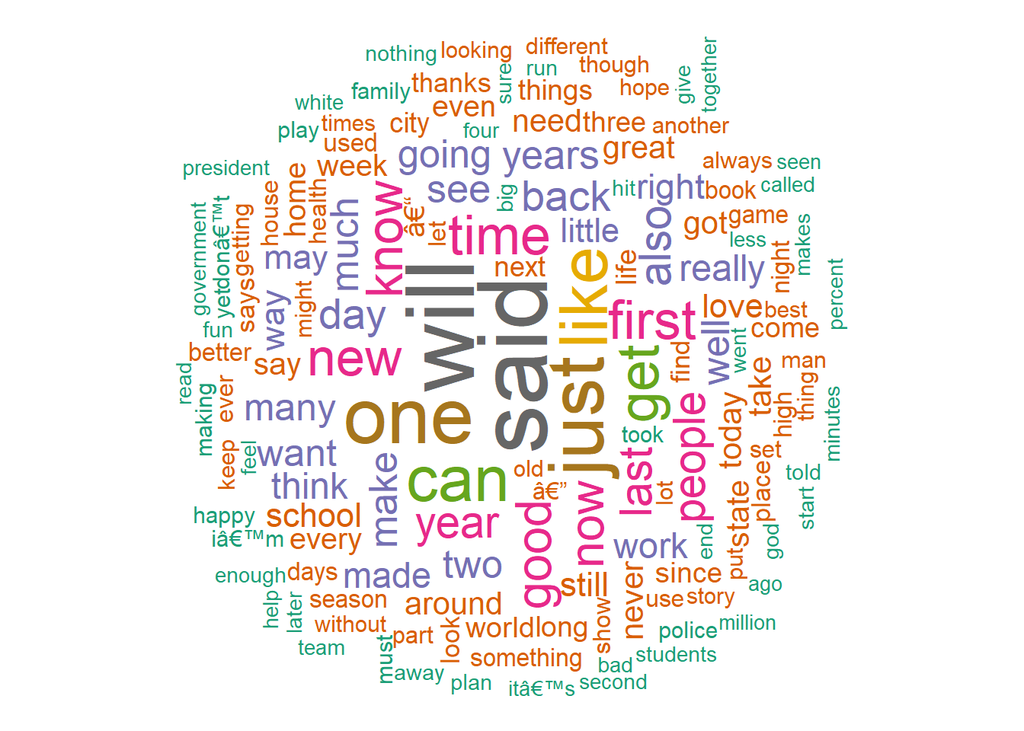

```r
uniMatrix <- as.matrix(uni)
uniMatrix <- sort(rowSums(uniMatrix),decreasing=TRUE)
uniMatrix <- data.frame(word = names(uniMatrix),freq=uniMatrix)
wordcloud(words = uniMatrix$word, freq = uniMatrix$freq, min.freq = 1,
          max.words=150, random.order=FALSE, rot.per=0.35,
          colors=brewer.pal(8, "Dark2"),main="1-gram")
```

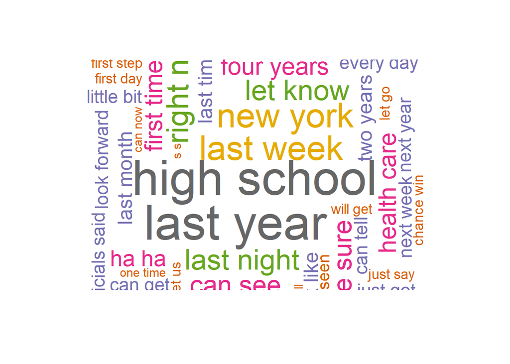

```r
biMatrix <- as.matrix(bi)
biMatrix <- sort(rowSums(biMatrix),decreasing=TRUE)
biMatrix <- data.frame(word = names(biMatrix),freq=biMatrix)
wordcloud(words = biMatrix$word, freq = biMatrix$freq, min.freq = 1,
          max.words=150, random.order=FALSE, rot.per=0.35,
          colors=brewer.pal(8, "Dark2"),main="2-gram")
```

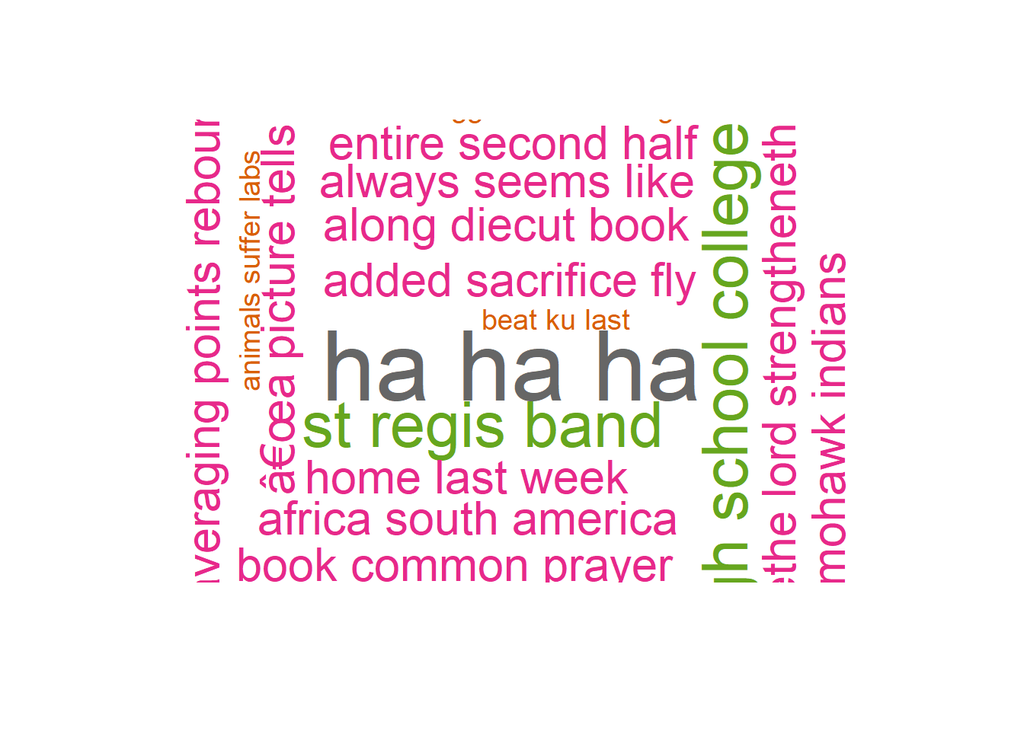

```r
threeMatrix <- as.matrix(three)
threeMatrix <- sort(rowSums(threeMatrix),decreasing=TRUE)
threeMatrix <- data.frame(word = names(threeMatrix),freq=threeMatrix)
wordcloud(words = threeMatrix$word, freq = threeMatrix$freq, min.freq = 1,
          max.words=150, random.order=FALSE, rot.per=0.35,
          colors=brewer.pal(8, "Dark2"),main="3-gram")
```

The most frequent words are also shown, to get a glimpse of the data. First we need to sort the grams by frequency

```r
getFreq <- function(tdm) {
  freq <- sort(rowSums(as.matrix(tdm)), decreasing = TRUE)
  return(data.frame(word = names(freq), freq = freq))
}

# Get frequencies of most common n-grams in data sample
uniFreq <- getFreq(uni)
biFreq <- getFreq(bi)
threeFreq <- getFreq(three)
```

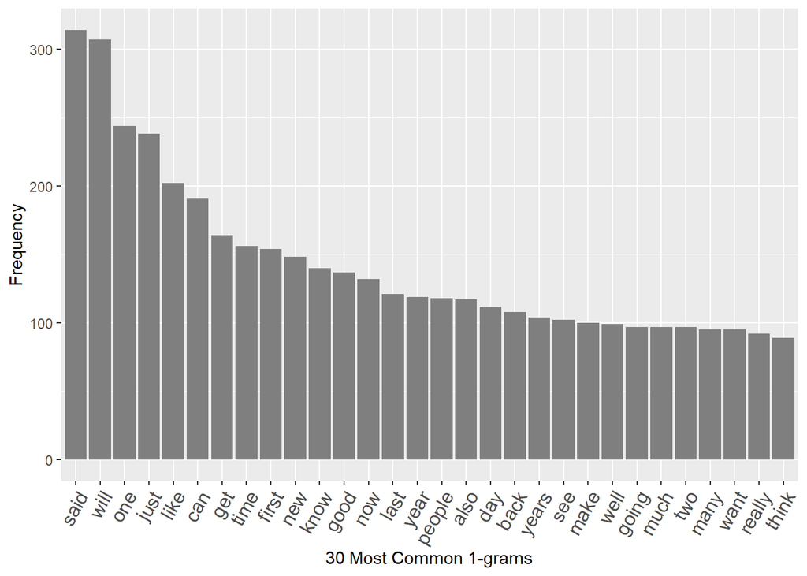

```r
makePlot <- function(data, label) {
  ggplot(data[1:30,], aes(reorder(word, -freq), freq)) +
         labs(x = label, y = "Frequency") +
         theme(axis.text.x = element_text(angle = 60, size = 12, hjust = 1)) +
         geom_bar(stat = "identity", fill = I("grey50"))
}

par(mfrow=c(1,3))
makePlot(uniFreq, "30 Most Common 1-grams")
```

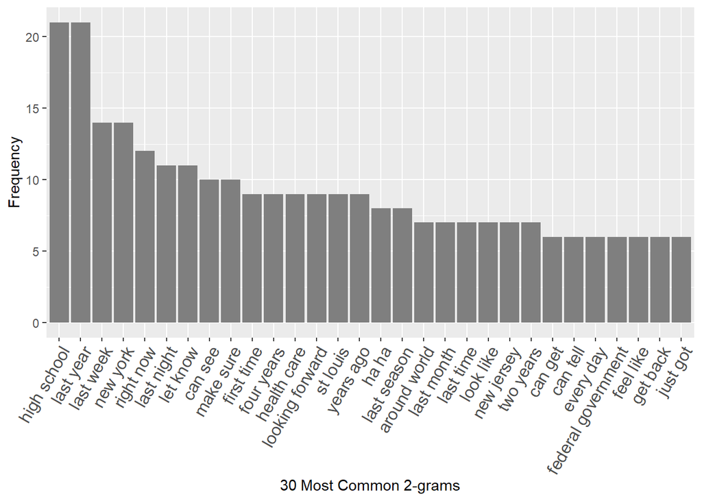

```r
makePlot(biFreq, "30 Most Common 2-grams")
```

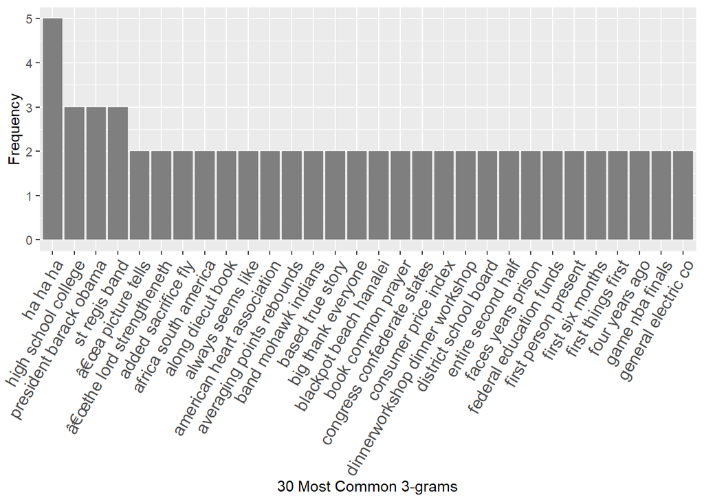

```r
makePlot(threeFreq, "30 Most Common 3-grams")
```

## Next Step: Model design

As nexts steps, a model will be constructed that will be able to predict the most likely word to follow a phrase.